# APS - R para Ciênca dos Dados

Kevin Saraiva, Thaíza Loiola e Yuri Freitas

30/05/2022

# 1 Introdução

A violência contra a mulher é um tema em crescente debate público devido à sua abrangência e impacto na sociedade brasileira, bem como aos danos causados pela negligência em relação a ele em décadas anteriores. De acordo com dados do [Fórum Brasileiro de Segurança Pública](https://forumseguranca.org.br/wp-content/uploads/2022/03/violencia-contra-mulher-2021-v5.pdf), entre março de 2020 e dezembro de 2021 houve 2.451 feminicídios e 100.398 casos de estupro e estupro de vulneráveis de vítimas do gênero feminino. Em 2021, houve um decréscimo nos casos de feminício em 2,4% em relação ao ano anterior; entretanto, os casos de estupro crescerem em 3,7%. Em média, em 2021 uma mulher foi vítima de feminicídio no Brasil a cada 7 horas e de estupro a cada dez minutos.

Além disso, a violência contra a mulher não se restringe à física ou sexual: as violências psicológica/moral, doméstica e, no caso infantojuvenil, negligência e abandono existem e são relevantes para compreender o conjunto de violências que aflingem as mulheres. Por esse motivo, investigar as possíveis causas e características do perfil da violência sofrida pelas mulheres no Brasil é relevante para o diagnóstico dessa conjuntura - e um bom diagnóstico é o passo inicial de políticas públicas que visam amenizar reduzir o impacto desse problema. Neste trabalho, pois, investigaremos como a violência contra a mulher se dá no Brasil, inicialmente com uma visão geral do cenário e fazendo comparações com a violência sofrida por homens para depois adentrarmos em mais detalhes acerca das características das violências sofridas pelo grupo social em questão.

# 2 Descrição da base de dados

A base de dados utilizada para investigar sa origens e características da violência é a do Sistema de Informação de Agravos de Notificação (SINAN) que, desde 2007, centraliza as informações de doenças e agravos no Brasil. Além disso, desde 2009 o SINAN também registra dados de violência interpessoal (na qual uma ou mais pessoas inflingem violência em alguém) e autoprovocada (suicida) pelo Sistema de Vigilância de Violência e Acidentes (VIVA), que contém os dados que são usados neste trabalho.

A [base extraída do SINAN](https://basedosdados.org/dataset/br-ms-sinan) contém mais de 150 variáveis que detalham violências sofridas por residentes do Brasil de 2009 a 2019, com informações a nível individual, constituindo um conjunto de microdados com mais de 2 milhões de linhas. Entre as informações disponíveis, há desde de dados genéricos sobre os pacientes que sofreram ou se autoinfligiram violência, como idade, sexo, raça, escolaridade e ocupação, até dados específicos, como qual foi o tipo de arma utilizada na violência; se houve violência psicológica, física ou sexual; motivação da violência; e a se houve coleta de fluídos corporais, como sangue, pela equipe de investigação do caso de violência.

Com esses dados, é possível investigar se existem diferenças entre sexos, raças e outros subgrupos em relação à incidência da violência; verificar como os casos de violência evoluíram ao longo dos anos; entender características regionais da violência; e buscar correlações entre características das violências com diferentes tipos de grupos sociais.

Um detalhe importante a ser ponderado é que o número de observações cresceu a cada ano - e embora não haja uma explicação oficial do site do SINAN, é provável que mais centros ambulatórios e de violência passaram a reportar seus dados ao SINAN, e não que houve um aumento expressivo na violência e nos acidentes a cada ano. Desse modo, fomos prudentes ao fazer análises temporais e evitamos comparações em números absolutos ao longo dos anos - quando uma análise temporal é feita, ela é colocada em termos relativos.

Informações detalhadas sobre a metodologia do VIVA podem ser encontradas no [documento instrutivo da instituição](https://bvsms.saude.gov.br/bvs/publicacoes/viva_instrutivo_violencia_interpessoal_autoprovocada_2ed.pdf).

# 3 Análise

## 3.1 Importação das bibliotecas utilizadas

```r
# Importação e manipulação de base de dados
library("data.table")
library("tidyverse")
library("tibble")
library("readxl")

# Para facilitar a conversão de números no formato de porcentagem
library("scales")

# Para construir  a nuvem de palavras
library("RColorBrewer")
library("wordcloud2")
library("tm")

# Para construir o treemap
library("treemap")

# Para as random forests
library("ranger")

# Para o Boosting
library("gbm")

# Para avaliar os modelos gerados
library("ROCR")
library("pROC")

# Para gráfico SANKEY DIAGRAM
library("networkD3")

# Para gráfico Spider
library("fmsb")
```

## 3.2 Importação da base de dados

```r
# Extração a base de dados a partir do diretório definido pelo usuário
getwd()
```

```
## [1] "C:/Users/Yuri/Downloads/Insper/R para Ciência dos Dados"
```

Algumas colunas da base de dados foram removidas porque elas continham apenas o id, e não uma descrição do que a variável significa. Por exemplo: na variável “sexo_paciente”, encontram-se os valores “1” para o sexo “masculino” e “2” para o sexo “feminino”, mas essa forma de dispor a informação é pouco intuitiva e por isso a coluna foi removida. Entretanto, não há perda de informação para nenhuma das variáveis excluídas dado que as colunas com sufixo “_desc” contém as mesmas informações com a descrição, em português, do que cada um dos ids significam. Além disso, eliminamos algumas variáveis que não foram utilizadas na análise a fim de melhorar a performance computacional.

```r
# Importação da base de dados no formato DataTable, mais rápido do que no formato DataFrame
dt_violencia <- fread("total_microdados_viol_tratada.csv", showProgress = TRUE,
                      na.strings = c("",NA),
                      drop = c("outras_vezes_ocorrencia",
                               "sexo_paciente", "gestante_paciente",
                               "raca_paciente", "estado_civil_paciente",
                               "identidade_genero_paciente",
                               "orientacao_sexual_paciente",
                               "motivacao_violencia",
                               "violencia_relacionada_trabalho", "emitiu_cat",
                               "deficiencia_transtorno_paciente",
                               "deficiencia_mental_paciente",
                               "deficiencia_visual_paciente",
                               "deficiencia_mental_paciente",
                               "deficiencia_auditiva_paciente",
                               "transtorno_mental_paciente",
                               "transtorno_comportamental_paciente",
                               "outras_deficiencias_paciente",
                               "ocorreu_tortura", "ocorreu_violencia_sexual",
                               "ocorreu_trafico_ser_humano",
                               "ocorreu_violencia_financeira",
                               "ocorreu_trabalho_infantil",
                               "ocorreu_intervencao_legal",
                               "ocorreu_outra_violencia", "meio_forca",
                               "escolaridade_paciente",
                               "deficiencia_fisica_paciente",
                               "meio_ameaca",
                               "houve_outra_violencia_sexual",
                               "profilaxia_dst", "profilaxia_hiv",
                               "profilaxia_hepatite_b", "coleta_sangue",
                               "coleta_semen", "aborto",
                               "local_ocorrencia_desc", "id_categoria_cid10",
                               "tipo_notificacao", "ocorreu_negligencia",
                               "ocorreu_negligencia_abandono", "emitiu_cat",
                               "id_municipio_6_notificacao",
                               "outro_local_ocorrencia",
                               "deficiencia_transtorno_paciente_desc",
                               "deficiencia_mental_paciente_desc",
                               "deficiencia_visual_paciente_desc",
                               "deficiencia_mental_paciente_desc",
                               "transtorno_mental_paciente_desc",
                               "transtorno_comportamental_paciente_desc",
                               "outras_deficiencias_paciente_desc",
                               "proxila", "profilaxia_dst_desc",
                               "profilaxia_hiv_desc",
                               "profilaxia_hepatite_b_desc",
                               "coleta_sangue_desc", "coleta_semen_desc",
                               "coleta_secrecao_vaginal",
                               "coleta_secrecao_vaginal_desc",
                               "profilaxia_contraceptivo",
                               "profilaxia_contraceptivo_desc"))

# O tempo de carregamento da base de dados é entre 2 e 3 minutos
```

```r
# Converter do formato DataTable para o formato Tibble
tb_violencia <- as_tibble(dt_violencia)

# Remover o DataTable para evitar duplicidade de informações
rm(dt_violencia)
```

Originalmente, a base de dados importada não contém a descrição das categorias e subcategorias das violências. Desse modo, é necessário fazer a mesclagem da tabela do SINAN com o dicionário de categorias e subcategorias do VIVA.

```r
# Importação da base de dados com a descrição das categorias e subcategorias do VIVA
cid_10_categorias = read_excel("cid_10_categorias_subcategorias.xlsx")
cid_10_categorias <- cid_10_categorias %>%
  as_tibble(cid_10_categorias)
```

```r
# Limpeza dos dados
tb_violencia$id_subcategoria_cid10 <- sub('\\.','',tb_violencia$id_subcategoria_cid10)

cid_10_categorias$subcategoria_cid <- sub('\\.','',cid_10_categorias$subcategoria_cid)

# Mesclagem dos dados
tb_violencia <- tb_violencia %>%
  left_join(cid_10_categorias,
            by = c("id_subcategoria_cid10" = "subcategoria_cid"),
            )
```

Também é feito uma junção a fim entender melhor a visão por região geográfica. Depois de realizar os *joins*, uma nova coluna é feita discriminando qual região cada estado pertence (Norte, Sul, Sudeste, Nordeste ou Centro-Oeste)

```r
# Importação da base de dados da base de municipios do ibge
municipio = read_excel("regioes_brasil_ibge.xlsx")
municipio <- municipio %>%   as_tibble(municipio)

# Separando valores de UF
regiao <- municipio %>% subset(select=c('UF','Nome_UF')) %>% unique
colnames(regiao) <- c('id_uf_notificacao','uf_notificacao')

# Valores por municipio
cidade <- municipio %>% subset(select = c('Nome_Mesorregião','Código Município Completo','Nome_Município') ) %>% unique
colnames(cidade) <- c('mesoregiao_notificacao','id_municipio_notificacao','municipio_notificacao')
```

```r
# Mesclagem dos dados
tb_violencia <- tb_violencia %>% left_join(regiao, by = 'id_uf_notificacao')
tb_violencia<- tb_violencia %>% left_join(cidade, by = 'id_municipio_notificacao')
```

```r
tb_violencia <- tb_violencia %>%  mutate(regiao= ifelse(uf_notificacao %in% c('Paraná','Santa Catarina','Rio Grande do Sul'), 'Sul',
                                                  ifelse(uf_notificacao %in% c('São Paulo','Rio de Janeiro','Espírito Santo','Minas Gerais'),'Sudeste',
                                                  ifelse(uf_notificacao %in% c('Acre', 'Amazonas', 'Amapá', 'Pará', 'Rondônia', 'Roraima', 'Tocantins'),'Norte',
                                                  ifelse(uf_notificacao %in% c('Alagoas', 'Bahia', 'Ceará', 'Maranhão', 'Piauí', 'Pernambuco', 'Paraíba', 'Rio Grande do Norte', 'Sergipe'),'Nordeste',
                                                  ifelse(uf_notificacao %in% c('Centro Oeste','Goiás', 'Mato Grosso', 'Mato Grosso do Sul','Distrito Federal'),'Centro Oeste',NA
                                                                       ))))))
```

## 3.3 Distribuição dos dados

Antes de iniciar as análises dos dados, é importante compreender como os dados se distribuem na base. É preciso investigar, por exemplo, quais as variáveis têm maiores e menores números de observações nulos, bem como entender se variáveis com alto percentual de NAs têm esse comportamento porque não foram coletadas nos anos iniciais da pesquisa ou porque de fato foram pouco preenchidas.

```r
# Cria tabela com o percentual de preenchimento de cada variável
percentual_preenchimento_col <-
  sapply(tb_violencia, function(x) sum(!is.na(x))/nrow(tb_violencia)) %>%
  stack(.) %>% # Transforma em DataFrame
  setNames(., c("percentual_preenchimento", "variavel")) %>%
  mutate(percentual_preenchimento_formatado = percent(percentual_preenchimento, 0.01),
        percentual_preenchimento = round(percentual_preenchimento, 4)) %>%
    .[, c("variavel", "percentual_preenchimento_formatado", "percentual_preenchimento")] %>%
  arrange(., desc(percentual_preenchimento))

view(percentual_preenchimento_col)

# Percentual de variáveis com menos de 20% de valores nulos
percent(length(which(percentual_preenchimento_col$percentual_preenchimento >= 0.8))/length(percentual_preenchimento_col$percentual_preenchimento), 0.01)
```

```
## [1] "74.19%"
```

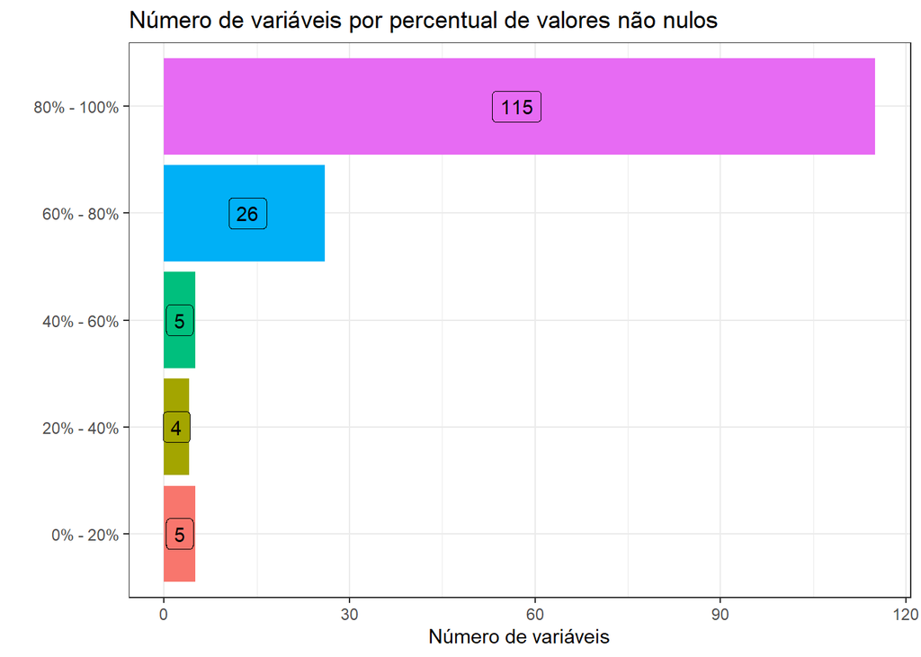

```r
# Definir o tema de plotagem dos gráficos globalmente
theme_set(theme_bw())

# Gráfico com o número de variáveis por percentual de valores não nulos
percentual_preenchimento_col %>%
    mutate(percentual_preenchimento = ifelse(percentual_preenchimento >= 0.8, "80% - 100%", ifelse(percentual_preenchimento >= 0.6, "60% - 80%", ifelse(percentual_preenchimento >= 0.4, "40% - 60%", ifelse(percentual_preenchimento >= 0.2, "20% - 40%", "0% - 20%"))))) %>%
  group_by(percentual_preenchimento) %>%
  summarise(contagem = n()) %>%
   ggplot(aes(percentual_preenchimento, contagem, fill = percentual_preenchimento)) +
         geom_col() +
           coord_flip() +
  geom_label(aes(y = c(2.5, 2, 2.5, 13.5, 57), label = contagem), label.padding = unit(0.3, "lines")) +
         theme(legend.position = "none") +
         labs(title = "Número de variáveis por percentual de valores não nulos",
              x = "",
              y = "Número de variáveis")
```

## 3.4 Análise exploratória inicial

```r
#cria um dataframe apenas com a quantidade de pacientes por ano
anos_df <- tb_violencia %>% count(ano, sort = TRUE)

#cria um dataframe apenas com a quantidade de pacientes por perfil racial
racas_df <- tb_violencia %>% count(raca_paciente_desc, sort = TRUE)

#cria um dataframe apenas com a quantidade de pacientes por gênero
sexos_df <- tb_violencia %>% count(sexo_paciente_desc, sort = TRUE)
```

No gráfico abaixo temos a evolução no número de pacientes por ano. Conforme é possível ver, os valores subiram bastante ano a ano. Entretanto, é importante fazer um aviso sobre esse comportamento dos dados: uma das hipóteses é de que esse aumento tenha sido gerado em função da própria melhor documentação das ocorrências por parte do governo, haja vista a estrutura de coleta de dados um pouco mais rudimentar que o governo tinha na última década. Consequentemente, é possível que exista um viés de seleção nessa base, tendo em vista a melhor estrutura de dados que o governo passou a contar mais recentemente, podendo assim, documentar melhor os casos de violência.

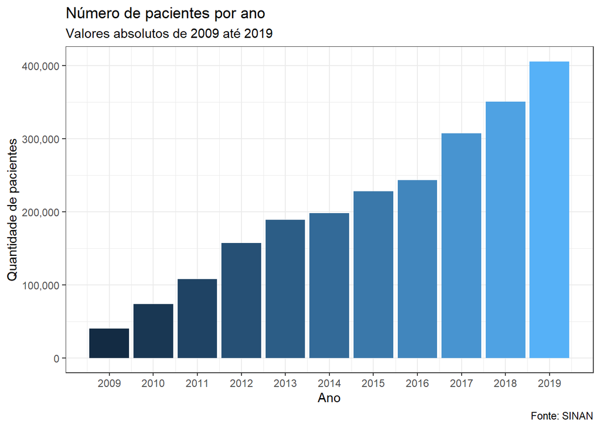

```r
# Gráfico de barras com as quantidades de pacientes por ano
anos_df %>%
  modify_if(is.integer, as.character) %>%
  ggplot(aes_(x=anos_df$ano, y=anos_df$n, fill=anos_df$ano)) +
  scale_x_continuous(breaks = 0:2100) +
  scale_y_continuous(labels = comma) +
  geom_bar(stat='identity') +
  labs(x = "Ano",
       y = "Quantidade de pacientes",
       title = "Número de pacientes por ano",
       subtitle = paste0("Valores absolutos de ", min(tb_violencia$ano), " até ", max(tb_violencia$ano)),
       caption = "Fonte: SINAN") +
  theme(legend.position = "none")
```

```r
# DF com as quantidadades de pacientes agrupadas por gênero e ano
grouped_by_ano_sexo <- tb_violencia[, c("sexo_paciente_desc", "ano")] %>%
  filter(sexo_paciente_desc != "") %>%
  count(ano, sexo_paciente_desc, sort = FALSE) %>%
  filter(across(everything(), ~ !is.na(.x)))
```

Ademais, quando segmentamos os dados por sexo é possivel observar que em todos os anos há um expressivo número de pacientes mulheres em comparação ao de homens, o que nos leva a crer que pode haver um grupo específico que pode estar mais suscetível a enfrentar violencia. Porém, é cabível aqui fazer uma nova ponderação: pode ser que a base tenha viés de seleção, pois é possível que mulheres denunciem mais as violências sofridas do que homens. Essa distinção de abordagens pode, por si, só enviesar a base para transmitir uma informação um pouco diferente do que o que é a realidade.

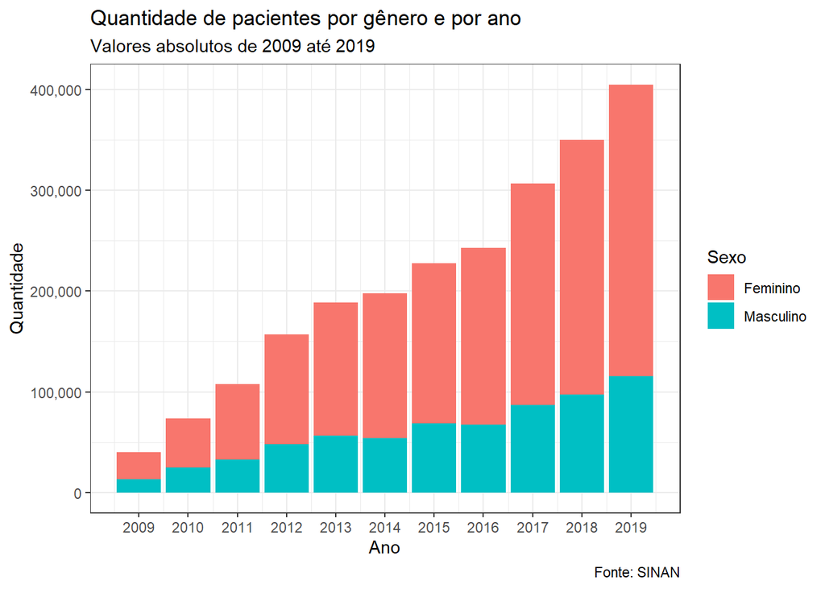

```r
# Gráfico de barras com as quantidades de pacientes por gênero por cada ano
ggplot(grouped_by_ano_sexo, aes(fill=sexo_paciente_desc, y=n, x=ano)) +
  geom_bar(position="stack", stat="identity") +
  scale_x_continuous(breaks = 0:2100) +
  scale_y_continuous(labels = comma) +
  labs( x= "Ano", y= "Quantidade", color= "",
        title = "Quantidade de pacientes por gênero e por ano",
        subtitle = paste0("Valores absolutos de ", min(tb_violencia$ano), " até ", max(tb_violencia$ano)),
        caption = "Fonte: SINAN",
        fill = "Sexo")
```

Ademais, quando olhamos os dados em valores absolutos, é possível notar que para todo o período o maior número de casos de violências reportadas foram vivenciados por pessoas brancas, seguidas das pessoas pardas. Neste espaço há também um outro risco de viés: pode ocorrer que as notificações não sejam adequadamente registradas para algum grupo etnico específico - por exemplo, pessoas pretas e pardas. Por sua vez, situações como essas podem contribuir para uma subnotificação, gerando também um viés de seleção nos dados. Ademais, é importante destacar que esses dados estão em valores absolutos e que seria interessante também observá-los de forma relativa em relação ao percentual da população que se autodeclara em cada tipo racial.

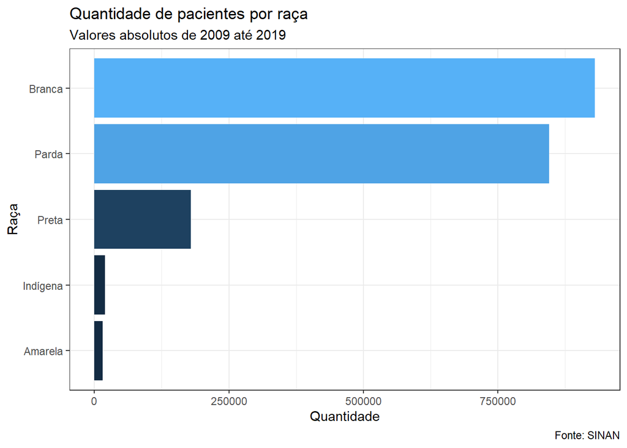

```r
racas_df$raca_paciente_desc <- as.character(racas_df$raca_paciente_desc)

# Gráfico de barras com as quantidades de pacientes por raça
racas_df %>%
  filter(raca_paciente_desc != "") %>%
  ggplot(aes(x=reorder(raca_paciente_desc,n),
             y=n,
             fill=n,
             na.rm = TRUE)) +
  geom_bar(stat='identity') +
  labs(x = "", y = "Quantidades", title = "Raça dos pacientes") +
  coord_flip() +
  theme(legend.position = "none") +
  labs( x= "Raça", y= "Quantidade", color= "",
        title = "Quantidade de pacientes por raça",
        subtitle = paste0("Valores absolutos de ", min(tb_violencia$ano), " até ", max(tb_violencia$ano)),
        caption = "Fonte: SINAN")
```

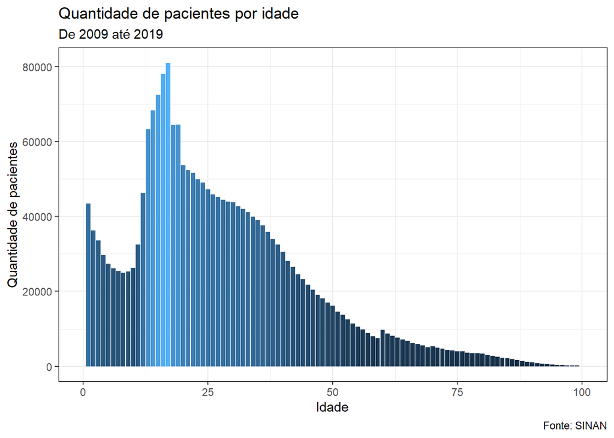

```r
qtd_idades <- tb_violencia[, c('idade_paciente')] %>% count(idade_paciente, sort = FALSE)

# Gráfico de barras com as quantidades de pacientes por idade
ggplot(qtd_idades, aes(x=idade_paciente, y=n, fill=n)) +
  geom_bar(stat='identity') +
  theme(legend.position = "none") +
  labs( x= "Idade", y= "Quantidade de pacientes", color= "",
        title = "Quantidade de pacientes por idade",
        subtitle = paste0("De ", min(tb_violencia$ano), " até ", max(tb_violencia$ano)),
        caption = "Fonte: SINAN") +
  xlim(0, 100)
```

```r
qtd_idades_por_ano <- tb_violencia[, c('idade_paciente','ano')] %>%
  group_by(ano, idade_paciente)
```

Quando fazemos a mesma verificação de frequência de ocorrências por idade segmentada por sexo é possível notar que o sexo feminino apresenta muito mais casos de vítimas de violência para uma mesma idade que homens na faixa dos 15 aos 65 anos de idade. Além disso, o padrão de quantidade de vítimas de violência passa a ser similar para homens bem como para mulheres nas demais faixas de idade.

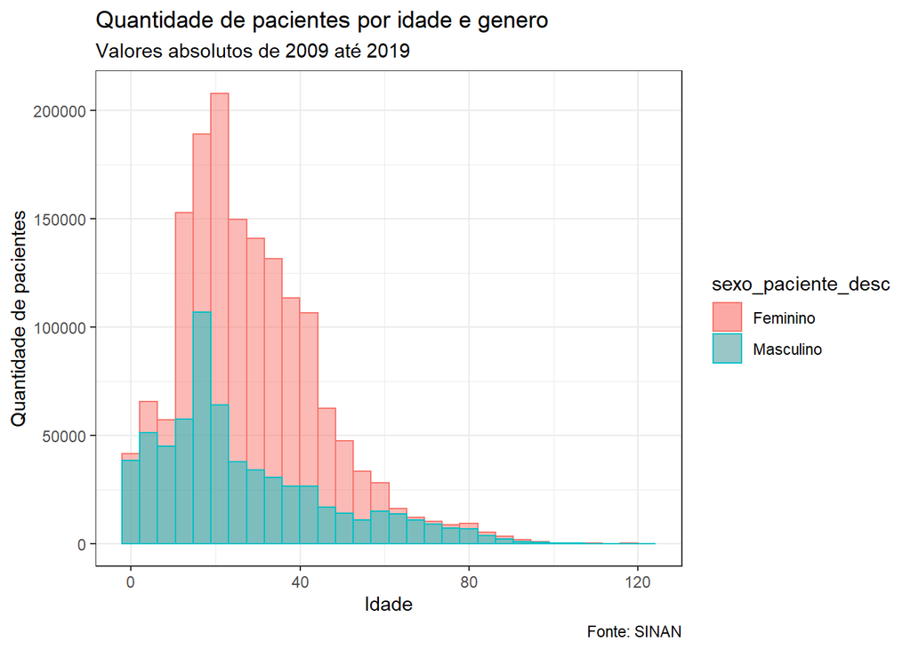

```r
# Gráfico de barras com as quantidades de pacientes por idade e genero
tb_violencia %>%
  filter(sexo_paciente_desc != "") %>%
  ggplot(aes(x=idade_paciente, color=sexo_paciente_desc, fill=sexo_paciente_desc)) +
  #geom_histogram(aes(y=..density..), colour="black", fill="white") +
  geom_histogram(position="identity", alpha=0.5) +
  geom_density(alpha=.2, fill="#FF6666") +
  #theme(legend.position = "none") +
  labs( x= "Idade", y= "Quantidade de pacientes",# color= "",
        title = "Quantidade de pacientes por idade e genero",
        subtitle = paste0("Valores absolutos de ", min(tb_violencia$ano), " até ", max(tb_violencia$ano)),
        caption = "Fonte: SINAN")
```

Este outro gráfico nos mostra o *boxplot* dos casos de violência por ano. Com ele é possível notar que a mediana dos casos manteve-se numa faixa etária em torno dos 24 anos. Adicionalmente, as caixas são razoavelmente pequenas, o que significa que há muita concentração de cados em torno dos 15-30 anos de idade para todos os anos. Há também uma expressiva quantidade de *outliers* em idades mais avançadas para todos os anos do período estudado.

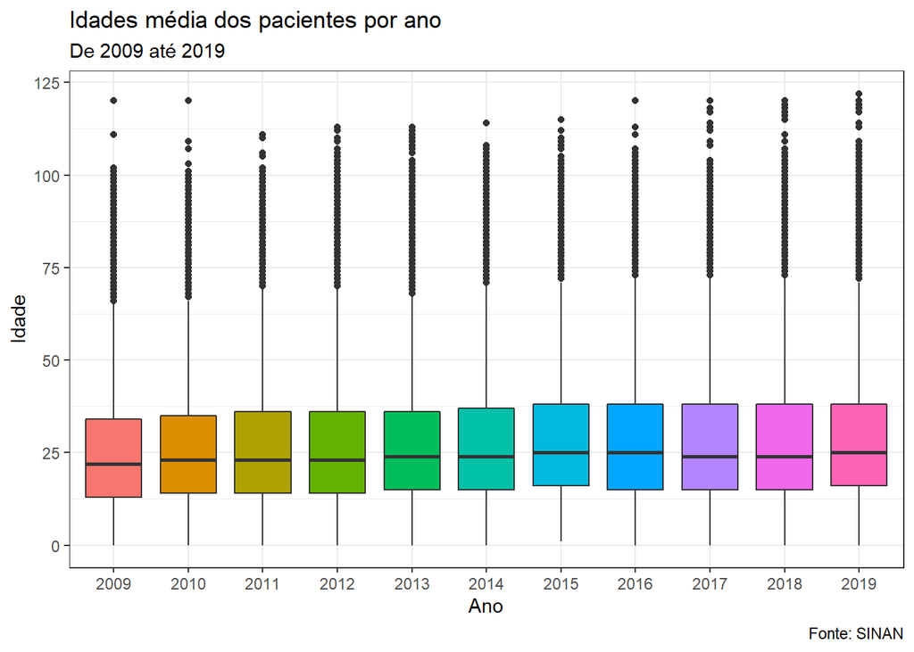

```r
# Boxplot com as quantidades de pacientes por idade
tb_violencia %>%
  mutate(ano = as.character(ano)) %>%
  ggplot(aes(x=ano, y=idade_paciente, fill=ano)) +
  geom_boxplot() +
  ggtitle("Idades média dos pacientes por ano") +
  theme(legend.position = "none") +
  labs( x= "Ano", y= "Idade", color= "",
        title = "Idades média dos pacientes por ano",
        subtitle = paste0("De ", min(tb_violencia$ano), " até ", max(tb_violencia$ano)),
        caption = "Fonte: SINAN")
```

E será que existe diferença significativa nos casos de violência reportados entre os sexos?

```r
# Agrupar o número de casos por sexo para analisar o percentual
sexos_tb <- tb_violencia %>%
  count(sexo_paciente_desc, sort = TRUE, name = "casos") %>%
  filter(sexo_paciente_desc != "" & !is.na(sexo_paciente_desc)) %>%
  rename(., sexo = sexo_paciente_desc) %>%
  mutate(percentual = casos/sum(casos),
         ymax = cumsum(percentual),
         ymin = c(0, head(ymax, n = -1)),
         posicao = (ymax + ymin)/2,
         legenda = paste(sexo, "\n", percent(percentual, 0.1)))
```

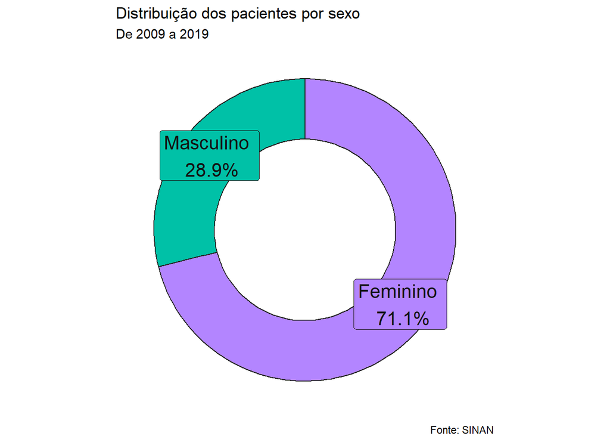

```r
# Plotagem do gráfico
ggplot(sexos_tb, aes(ymax = ymax, ymin = ymin, xmax = 3, xmin = 4,
                     fill = sexo)) +
  geom_rect(color = "gray14") +
  geom_label(x = 3.5, aes(y = posicao, label = legenda), size = 5.5,
             color = "gray7") +
  scale_fill_manual(values = c("#B385FF", "#00C1A7")) +
  coord_polar(theta = "y") +
  xlim(c(1.5, 4)) +
  labs(title = "Distribuição dos pacientes por sexo",
    subtitle = "De 2009 a 2019",
    caption = "Fonte: SINAN") +
  theme_void() +
  theme(legend.position = "none")
```

Os dados indicam que, entre 2009 e 2019, as mulheres sofreram 71,1% da violência interpessoal e autopraticada, enquanto os homens sofreram 28,9%. Dado que, segundo a [PNAD Contínuda de 2019](https://educa.ibge.gov.br/jovens/conheca-o-brasil/populacao/18320-quantidade-de-homens-e-mulheres.html), as mulheres representavam 51,8% da população brasileira (e que esse percentual não variou significativamente entre o período analisado), existe um claro desbalanço da violência sofrida (ou ao reportada) entre mulheres e homens.

Como esses dados de violência variaram ao longo dos 10 anos de análise?

```r
# Construção de uma tabela (tibble) com o número de casos de violência sofridos pelas mulheres em relação ao total do número de casos
casos_sexo_ano_percentual <- tb_violencia[, c("sexo_paciente_desc", "ano")] %>%
  count(ano, sexo_paciente_desc, sort = FALSE) %>%
  filter(sexo_paciente_desc == "Feminino") %>%
  select(-sexo_paciente_desc) %>%
  rename(., pacientes_fem = "n") %>%
  # Unir a tabela de pacientes do sexo feminino com o total
  left_join(
    tb_violencia[, c("sexo_paciente_desc", "ano")] %>%
      filter(sexo_paciente_desc != "" & !is.na(sexo_paciente_desc)) %>%
      group_by(ano) %>%
      summarise(total = n()), by = c("ano" = "ano")) %>%
  mutate(percentual_fem = pacientes_fem/total,
         percentual_masc = 1 - percentual_fem,
         ano = as.factor(ano))

# Visualizar a tabela
view(casos_sexo_ano_percentual)
```

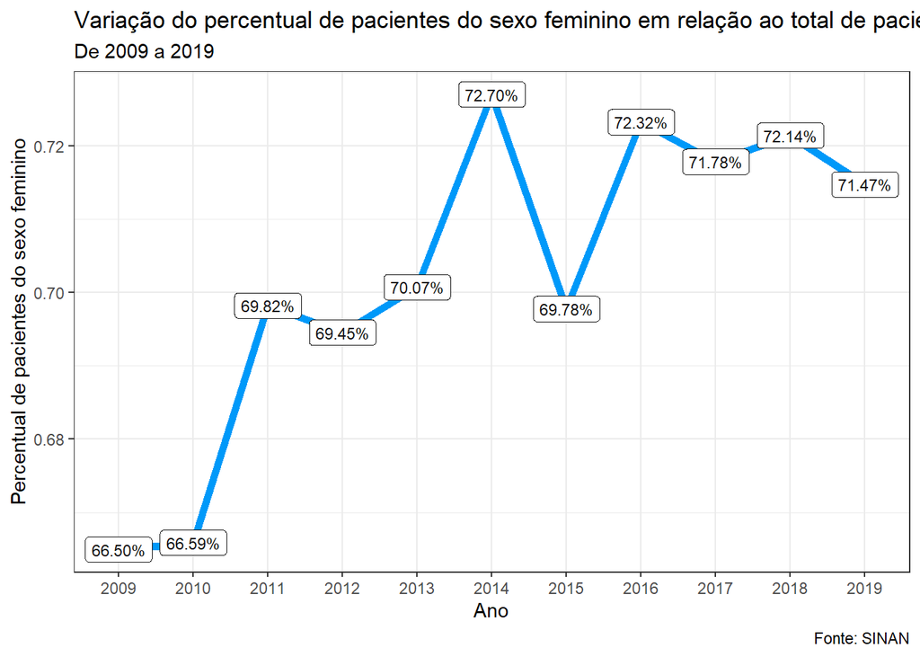

```r
# Criar o gráfico de linha que mostra a variação percentual de pacientes do sexo feminino entre 2009 e 2019
ggplot(data = casos_sexo_ano_percentual, aes(x = ano,
                                             y = percentual_fem,
                                             group = 1)) +
  geom_line(color = "#0099f9", size = 2) +
  geom_point(color = "#0099f9", size = 4) +
  geom_label(
    aes(label = percent(percentual_fem, 0.01)),
    size = 3,
    color = "grey7"
  ) +
  labs(title = "Variação do percentual de pacientes do sexo feminino em relação ao total de pacientes",
       subtitle = "De 2009 a 2019",
       caption = "Fonte: SINAN",
       x = "Ano",
       y = "Percentual de pacientes do sexo feminino")
```

O gráfico indica que o houve um crescimento do percentual de casos de violência que as mulheres sofreram em relação ao total de casos no período analisado. Houve variações significativas entre 2010 e 2011 (aumento de 3 pontos percentuais), 2014 e 2015 (queda de 3 p.p.) e 2015 e 2016 (aumento de 2,5 p.p.). Após esse período de considerável variação, há uma leve tendência de queda desde 2016.

Dadas as análises feitas acima, vale a pena investigar como os tipos de violência sofridas por homens e mulheres se diferem. Antes de fazer essa análise, porém, é importante avaliar se o dado da subcategoria do CID-10 variou significativamente ao longo dos anos, dado que o percentual de valores não nulos dessa variável na base está apenas na casa dos 20%.

```r
cid_subcategoria_nna <- tb_violencia[, c("descricao_subcategoria", "ano")] %>%
  group_by(ano) %>%
  summarise(contagem = n()) %>%
  left_join(
    tb_violencia[, c("descricao_subcategoria", "ano")] %>%
      filter(!is.na(descricao_subcategoria)) %>%
        group_by(ano) %>%
  summarise(contagem_n_nas = n()),
      by = c("ano" = "ano")) %>%
  mutate(percentual_n_nas = percent(contagem_n_nas/contagem, 0.01))

cid_subcategoria_nna
```

```
## # A tibble: 11 × 4
##      ano contagem contagem_n_nas percentual_n_nas
##    <int>    <int>          <int> <chr>
##  1  2009    39972           7180 17.96%
##  2  2010    73787          13101 17.76%
##  3  2011   107511          19305 17.96%
##  4  2012   157012          33374 21.26%
##  5  2013   188703          34019 18.03%
##  6  2014   198057          34200 17.27%
##  7  2015   227852          44018 19.32%
##  8  2016   243192          54383 22.36%
##  9  2017   307307          66114 21.51%
## 10  2018   350308          77015 21.98%
## 11  2019   405441          88148 21.74%
```

A tabela indica que a informação de categoria do CID-10 esteve presente em todos os anos da análise. Embora o percentual de valores não nulos tenha crescido de 17% para 22%, não existe diferença expressiva que limite a análise ao longo dos anos.

Para investigar quais tipos de violência estão mais associadas a mulheres e hoemns, uma análise de um gráfico de nuvem de palavras (wordcloud) é útil.

```r
# Cria um "Corpus" (coleção de palavras) associadas à subcategoria da violência sofrida por mulheres
text_fem <- tb_violencia[, c("descricao_subcategoria", "sexo_paciente_desc")] %>%
  filter(!is.na(descricao_subcategoria) & sexo_paciente_desc == "Feminino") %>%
  select(descricao_subcategoria) %>%
  as.data.frame(.) %>%
  .$descricao_subcategoria


# Cria um "Corpus" (coleção de palavras) associadas à subcategoria da violência sofrida por homens
text_masc <- tb_violencia[, c("descricao_subcategoria", "sexo_paciente_desc")] %>%
  filter(!is.na(descricao_subcategoria) & sexo_paciente_desc == "Masculino") %>%
  select(descricao_subcategoria) %>%
  as.data.frame(.) %>%
  .$descricao_subcategoria
```

```r
memory.limit(size=1800)

# Lista de algumas stop words que foram encontradas com certa frequência na base de subcategorias
outras_stop_words = c("meio", "outra", "outras", "parte", "especificada", "especificadas", "classificados", "especificado")

# Cria um documento com a frequência de palavras associadas à subcategoria de violência sofrida por mulheres
docs_palavras_fem <- Corpus(VectorSource(text_fem)) %>%
  tm_map(removeNumbers) %>%
  tm_map(removePunctuation) %>%
  tm_map(stripWhitespace) %>%
  tm_map(., content_transformer(tolower)) %>%
  tm_map(., removeWords, c(stopwords("portuguese"), outras_stop_words))

# Cria um DataFrame com as palavras mais frequentes
dtm_palavras_fem <- TermDocumentMatrix(docs_palavras_fem)
matrix_palavras_fem <- as.matrix(dtm_palavras_fem)
palavras_fem <- sort(rowSums(matrix_palavras_fem), decreasing = TRUE)
df_palavras_fem <- data.frame(word = names(palavras_fem), freq = palavras_fem)
```

O mesmo processo é repetido para pessoas do sexo masculino.

```r
memory.limit(size=1800)

# Cria um documento com a frequência de palavras associadas à subcategoria de violência sofrida por homens
docs_palavras_masc <- Corpus(VectorSource(text_masc)) %>%
  tm_map(removeNumbers) %>%
  tm_map(removePunctuation) %>%
  tm_map(stripWhitespace) %>%
  tm_map(., content_transformer(tolower)) %>%
  tm_map(., removeWords, c(stopwords("portuguese"), outras_stop_words))

# Cria um DataFrame com as palavras mais frequentes
dtm_palavras_masc <- TermDocumentMatrix(docs_palavras_masc)
matrix_palavras_masc <- as.matrix(dtm_palavras_masc)
palavras_masc <- sort(rowSums(matrix_palavras_masc), decreasing = TRUE)
df_palavras_masc <- data.frame(word = names(palavras_masc), freq = palavras_masc)
```

```r
# Nuvem de palavras de violência associada às mulheres
wordcloud2(data = df_palavras_fem, size = 0.75, color = "random-dark")
```

[interactive chart not shown]

No caso das mulheres, as palavras “agressão”, “residência”, “força”, “corporal” e “sexual” são as que mais se destacam, o que pode indicar que boa parte da violência sofrida pelas mulheres é a doméstica com o uso da força física.

```r
# Tabela com o percentual de violência por força sofrida por homens e mulheres com o percentual relativo a cada sexo
tb_violencia[, c("sexo_paciente_desc", "meio_forca_desc")] %>%
    filter(!is.na(sexo_paciente_desc) & !is.na(meio_forca_desc)) %>%
  group_by( sexo_paciente_desc, meio_forca_desc) %>%
  summarise(numero_casos = n()) %>%
  mutate(freq = formattable::percent(numero_casos / sum(numero_casos))) %>%
  rename(., sexo = sexo_paciente_desc, meio_forca = meio_forca_desc)
```

```
## # A tibble: 4 × 4
## # Groups:   sexo [2]
##   sexo      meio_forca numero_casos freq
##   <chr>     <chr>             <int> <formttbl>
## 1 Feminino  Não              739963 48.26%
## 2 Feminino  Sim              793255 51.74%
## 3 Masculino Não              390913 64.02%
## 4 Masculino Sim              219709 35.98%
```

A tabela acima reforça que a força foi mais utilizada como meio de violência em vítimas do sexo feminino comparativamente ao masculino, dado que em 51,7% dos casos de violência contra mulher a violência foi utilizada, enquanto esse número foi de apenas 36% para os homens.

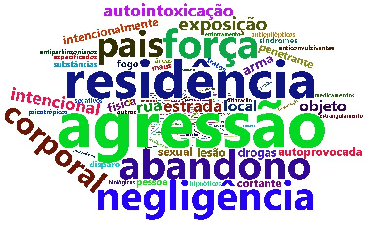

nuvem de palavras para homens - colocada como imagem devido a um bug não identificado na conversão do arquivo para HTML

```r
# Nuvem de palavras de violência associada aos homens
wordcloud2(data = df_palavras_masc, size = 0.75, color = "random-dark")
```

Já no caso dos homens, as 5 palavras que mais se repetem são “agressão”, “residência”, “negligência”, “abandono” e “pais”, o que sugere que, além da agressão, comum a homens e mulheres, há uma quantidade significativa de casos de violência com crianças do sexo masculino, evidenciada pelas palavras “negligência” e “abandono”. Para ter mais confiança acerca da veracidade dessa hipótese, prosseguimos com uma análise quantitativa da distribuição de pacientes do sexo masculino por idade.

```r
distribuicao_idade_homens <- tb_violencia[ , c("sexo_paciente_desc", "idade_paciente")] %>%
  filter(sexo_paciente_desc == "Masculino" & !is.na(idade_paciente)) %>%
  count(idade_paciente, sort = FALSE, name = "casos") %>%
  rename(., idade = idade_paciente) %>%
  mutate(grupos_idade = ifelse(idade >= 60, "Idoso", ifelse(idade >= 30, "Adulto", ifelse(idade >= 18, "Jovem Adulto", ifelse(idade >= 13, "Adolescente", "Criança"))))) %>%
  group_by(grupos_idade) %>%
  summarise(numero_casos = sum(casos)) %>%
  arrange(match(grupos_idade, c("Criança", "Adolescente", "Jovem Adulto", "Adulto", "Idoso"))) %>%
  mutate(percentual = numero_casos/sum(numero_casos),
         ymax = cumsum(percentual),
         ymin = c(0, head(ymax, n = -1)),
         posicao = (ymax + ymin)/2,
         legenda = paste(grupos_idade, "\n", percent(percentual, 0.1)))
```

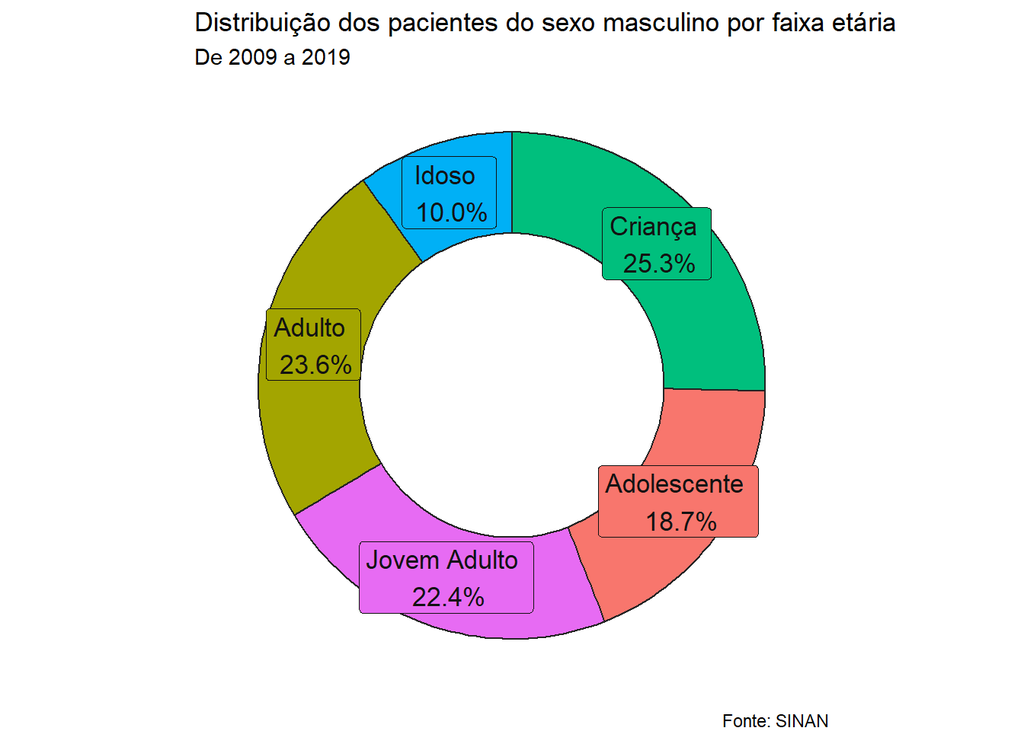

```r
ggplot(distribuicao_idade_homens, aes(ymax = ymax, ymin = ymin, xmax = 3, xmin = 4,
                     fill = grupos_idade)) +
  geom_rect(color = "gray14") +
  geom_label(x = 3.5, aes(y = posicao, label = legenda), size = 4.5,
             color = "gray7") +
  coord_polar(theta = "y") +
  xlim(c(1.5, 4)) +
  labs(title = "Distribuição dos pacientes do sexo masculino por faixa etária",
    subtitle = "De 2009 a 2019",
    caption = "Fonte: SINAN") +
  theme_void() +
  theme(legend.position = "none")
```

```r
distribuicao_idade_mulheres <- tb_violencia[ , c("sexo_paciente_desc", "idade_paciente")] %>%
  filter(sexo_paciente_desc == "Feminino" & !is.na(idade_paciente)) %>%
  count(idade_paciente, sort = FALSE, name = "casos") %>%
  rename(., idade = idade_paciente) %>%
  mutate(grupos_idade = ifelse(idade >= 60, "Idoso", ifelse(idade >= 30, "Adulto", ifelse(idade >= 18, "Jovem Adulto", ifelse(idade >= 13, "Adolescente", "Criança"))))) %>%
  group_by(grupos_idade) %>%
  summarise(numero_casos = sum(casos)) %>%
  arrange(match(grupos_idade, c("Criança", "Adolescente", "Jovem Adulto", "Adulto", "Idoso"))) %>%
  mutate(percentual = numero_casos/sum(numero_casos),
         ymax = cumsum(percentual),
         ymin = c(0, head(ymax, n = -1)),
         posicao = (ymax + ymin)/2,
         legenda = paste(grupos_idade, "\n", percent(percentual, 0.1)))
```

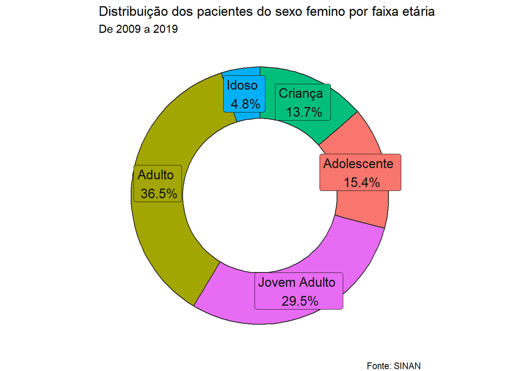

```r
ggplot(distribuicao_idade_mulheres, aes(ymax = ymax, ymin = ymin, xmax = 3, xmin = 4,
                     fill = grupos_idade)) +
  geom_rect(color = "gray14") +
  geom_label(x = 3.5, aes(y = posicao, label = legenda), size = 4.5,
             color = "gray7") +
  coord_polar(theta = "y") +
  xlim(c(1.5, 4)) +
  labs(title = "Distribuição dos pacientes do sexo femino por faixa etária",
    subtitle = "De 2009 a 2019",
    caption = "Fonte: SINAN") +
  theme_void() +
  theme(legend.position = "none")
```

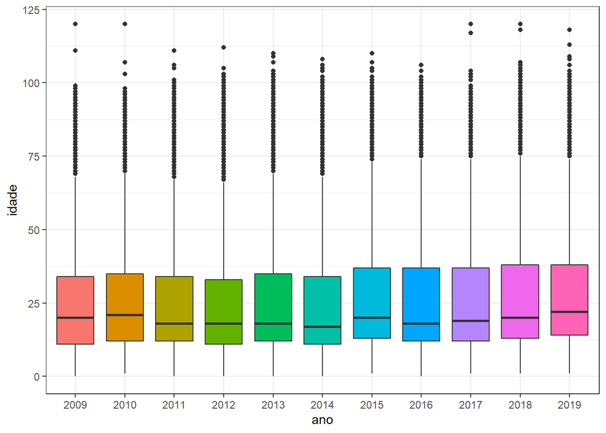

```r
tb_violencia[ , c("ano", "sexo_paciente_desc", "idade_paciente")] %>%
  filter(sexo_paciente_desc == "Masculino" & !is.na(idade_paciente)) %>%
  rename(., idade = idade_paciente) %>%
  group_by(ano) %>%
  mutate(ano = as.character(ano)) %>%
  ggplot(aes(x=ano, y=idade, fill=ano)) +
  geom_boxplot() +
  theme(legend.position = "none")
```

Além disso, o *boxplot* acima reforça a hipótese e indica que não houve variações expressivas e abruptas na distribuição da idade de pacientes do sexo masculino de ao longo dos anos (talvez com exceção de 2014). Essa evidência também reforça que comparar a soma do número de pacientes ao longo dos anos de acordo com seus grupos etários, como foi feito no gráfico de rosca, não é um procedimento metodologicamente errado.

De modo geral, o tipo mais comum de violência entre ambos os sexos é a agressão, que pode ser de diversas formas. Além disso, boa parte dos casos de violência - seja ela proposital ou não - geralmente ocorre na própria residência da vítima. O que difere homens e mulheres de maneira mais expressiva é que pessoas do sexo feminino sofrem um percentual maior de violência física e sexual, enquanto as do sexo masculino enfrentam mais problemas, em termos relativos, de negligência e abandono de seus pais e responsáveis.

A despeito da possibilidade real de viés de seleção dos dados, partindo do pressuposto de que os dados de fato refeltem a distribuição da violência na população brasileira, percebe-se que as mulheres representam o maior número casos de violência de modo desproporcional à distribuição da população. A partir disso, queremos investigar mais a fundo os fatores que compõem e influenciam a violência sofrida por esse grupo.

## 3.5 Análise da violência sofrida por pessoas sexo feminino

### 3.5.1 Com enfoque no aspecto racial

```r
violencia_mulheres_raca <- tb_violencia[c("sexo_paciente_desc", "raca_paciente_desc")] %>%
  filter(sexo_paciente_desc == "Feminino" & !is.na(raca_paciente_desc)) %>%
  group_by(raca_paciente_desc) %>%
  summarise(numero_casos = n()) %>%
  arrange(., desc(numero_casos)) %>%
  mutate(freq = formattable::percent(numero_casos / sum(numero_casos)),
           legenda = paste(numero_casos, "\n", freq))
```

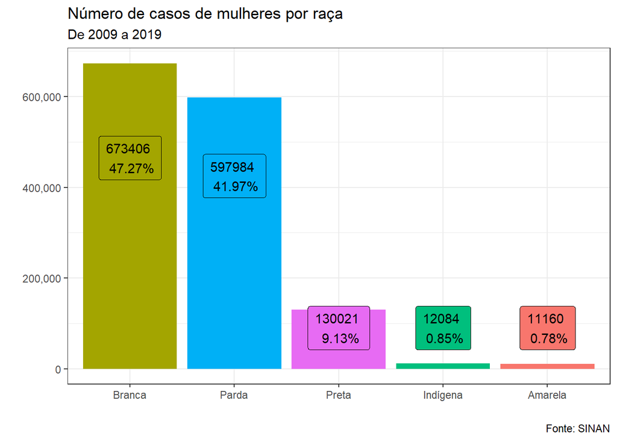

```r
violencia_mulheres_raca %>%
   ggplot(aes(x = reorder(raca_paciente_desc, -numero_casos), y = numero_casos, fill = raca_paciente_desc)) +
         geom_col() +
   scale_y_continuous(labels = comma) +
  geom_label(aes(y = c(465000, 425000, 90000, 90000, 90000), label = legenda), label.padding = unit(0.4, "lines")) +
         theme(legend.position = "none") +
         labs(title = "Número de casos de mulheres por raça",
              x = "",
              y = "",
              subtitle = "De 2009 a 2019",
              caption = "Fonte: SINAN")
```

```r
# Remoção das raças "indígena" e "amarela" da análise
racas_selecionadas <- c("Branca", "Parda", "Preta")

mulheres_raca_faixa_etaria <- tb_violencia[c("sexo_paciente_desc", "raca_paciente_desc", "idade_paciente")] %>%
  filter(sexo_paciente_desc == "Feminino" & !is.na(raca_paciente_desc) & raca_paciente_desc %in% racas_selecionadas) %>%
  mutate(grupos_idade = ifelse(idade_paciente >= 60, "Idoso", ifelse(idade_paciente >= 30, "Adulto", ifelse(idade_paciente >= 18, "Jovem Adulto", ifelse(idade_paciente >= 13, "Adolescente", "Criança"))))) %>%
  group_by(raca_paciente_desc, grupos_idade) %>%
  summarise(numero_casos = n()) %>%
  filter(!is.na(grupos_idade)) %>%
  mutate(freq = formattable::percent(numero_casos / sum(numero_casos))) %>%
  arrange(., desc(numero_casos))
mulheres_raca_faixa_etaria
```

```
## # A tibble: 15 × 4
## # Groups:   raca_paciente_desc [3]
##    raca_paciente_desc grupos_idade numero_casos freq
##    <chr>              <chr>               <int> <formttbl>
##  1 Branca             Adulto             250222 38.04%
##  2 Parda              Adulto             202625 34.66%
##  3 Branca             Jovem Adulto       189918 28.87%
##  4 Parda              Jovem Adulto       173465 29.67%
##  5 Parda              Adolescente         98712 16.88%
##  6 Branca             Adolescente         95913 14.58%
##  7 Parda              Criança             86876 14.86%
##  8 Branca             Criança             83379 12.67%
##  9 Preta              Adulto              50386 39.35%
## 10 Preta              Jovem Adulto        39143 30.57%
## 11 Branca             Idoso               38426 5.84%
## 12 Parda              Idoso               22990 3.93%
## 13 Preta              Adolescente         17981 14.04%
## 14 Preta              Criança             14615 11.41%
## 15 Preta              Idoso                5928 4.63%
```

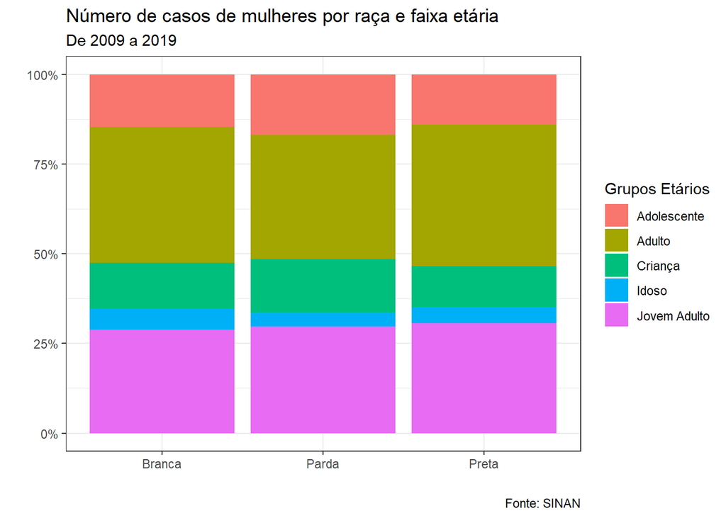

```r
ggplot(mulheres_raca_faixa_etaria, aes(fill = grupos_idade, y  = numero_casos, x = reorder(raca_paciente_desc, -numero_casos), label = freq)) +
    geom_bar(position="fill", stat="identity", width=0.9) +
  scale_y_continuous(labels = scales::percent)  +
           labs(title = "Número de casos de mulheres por raça e faixa etária",
              x = "",
              y = "",
              subtitle = "De 2009 a 2019",
              caption = "Fonte: SINAN",
              fill = "Grupos Etários")
```

### 3.5.2 Escolaridade

```r
escolaridade_violencia <- tb_violencia[c("sexo_paciente_desc", "escolaridade_paciente_desc")] %>%
  filter(!is.na(escolaridade_paciente_desc), sexo_paciente_desc == "Feminino" & escolaridade_paciente_desc != "Não se aplica") %>%
  group_by(escolaridade_paciente_desc) %>%
  summarise(numero_casos = n()) %>%
  mutate(freq = formattable::percent(numero_casos / sum(numero_casos)),
         legenda = paste(escolaridade_paciente_desc,"\n", freq))
```

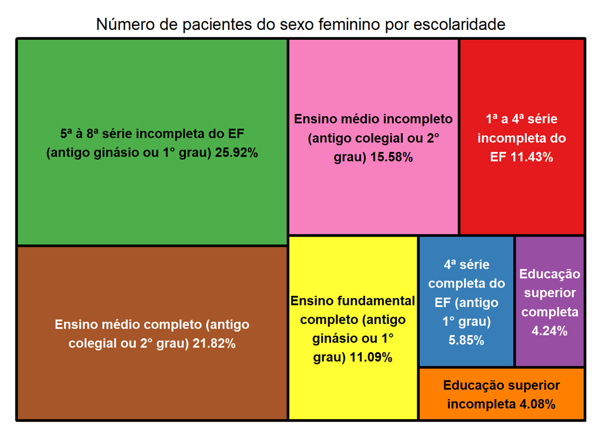

```r
treemap(escolaridade_violencia,
            index = "legenda",
            vSize = "numero_casos",
            type="index",
        palette = "Set1",
        title = "Número de pacientes do sexo feminino por escolaridade",
        border.lwds=c(3, 2)
            )
```

Os dados indicam que mulheres com ensino fundamental 2 incompleto são as que mais sofrem violência, com quase 26% de todos os casos, seguidas daquelas com ensino médio completo (21,8%) e com ensino méido incompleto (15,58%). O grupo que menos sofre violência - e que também representa uma parcela menor da população feminina - são as pessoas que completarem (4,24%) e não completaram (4,08%) o ensino superior. É difícil extrair conclusões desses dados, pois a distribuição assemelha-se à distribuição do grau de formação de mulheres no Brasil.

### 3.5.3 Origem da violência

```r
tb_violencia[c("sexo_paciente_desc", "motivacao_violencia_desc")] %>%
  filter(!is.na(motivacao_violencia_desc), sexo_paciente_desc == "Feminino" & motivacao_violencia_desc != "Não se aplica" & motivacao_violencia_desc != "Outros") %>%
  group_by(motivacao_violencia_desc) %>%
  summarise(numero_casos = n()) %>%
  mutate(freq = formattable::percent(numero_casos / sum(numero_casos))) %>%
  rename(., motivacao_violencia = motivacao_violencia_desc) %>%
  arrange(., desc(numero_casos))
```

```
## # A tibble: 8 × 3
##   motivacao_violencia                     numero_casos freq
##   <chr>                                          <int> <formttbl>
## 1 Sexismo                                       129640 50.00%
## 2 Conflito geracional                            98795 38.10%
## 3 Situação de rua                                16169 6.24%
## 4 Deficiência                                     8899 3.43%
## 5 Homofobia/Lesbofobia/Bifobia/Transfobia         3854 1.49%
## 6 Intolerância religiosa                           705 0.27%
## 7 Racismo                                          700 0.27%
## 8 Xenofobia                                        516 0.20%
```

Quando analisamos os fatores que explicam a motivação da violência contra mulheres desconsiderando “Outros” e “Não se aplica”, o sexismo é o mais relevante deles, com 50% dos casos reportados. Outro motivador bastante com da violência é o conflito geracional, que representa 38,1% dos casos na base. Vale, por fim, entender quem são os agentes causadores da violência contra as mulheres - a suspeita inicial, pela análise da motivação, é que sejam conjugues, namorados e familiares.

```r
autor_violencia_mulher <- tb_violencia[c("sexo_paciente_desc", "autor_mae", "autor_pai", "autor_padrasto", "autor_madrasta", "autor_conjugue", "autor_ex_conjugue", "autor_namorado_a", "autor_ex_namorado_a", "autor_filho_a", "autor_desconhecido")] %>%
  filter(sexo_paciente_desc == "Feminino") %>%
  mutate(autor_mae = sum(autor_mae, na.rm = TRUE),
         autor_pai = sum(autor_pai, na.rm = TRUE),
         autor_padrasto = sum(autor_padrasto, na.rm = TRUE),
         autor_madrasta = sum(autor_madrasta, na.rm = TRUE),
         autor_conjugue = sum(autor_conjugue, na.rm = TRUE),
         autor_ex_conjugue = sum(autor_ex_conjugue, na.rm = TRUE),
         autor_namorado_a = sum(autor_namorado_a, na.rm = TRUE),
         autor_ex_namorado_a = sum(autor_ex_namorado_a, na.rm = TRUE),
         autor_filho_a = sum(autor_filho_a, na.rm = TRUE),
         autor_desconhecido = sum(autor_desconhecido, na.rm = TRUE)) %>%
  slice(., 1) %>%
  t(.) %>%
  .[-1, ] %>%
  as.data.frame(.)


autor_violencia_mulher <- tibble::rownames_to_column(autor_violencia_mulher)
colnames(autor_violencia_mulher) <- c("autor", "numero_casos")
autor_violencia_mulher$numero_casos <- as.numeric(autor_violencia_mulher$numero_casos)
```

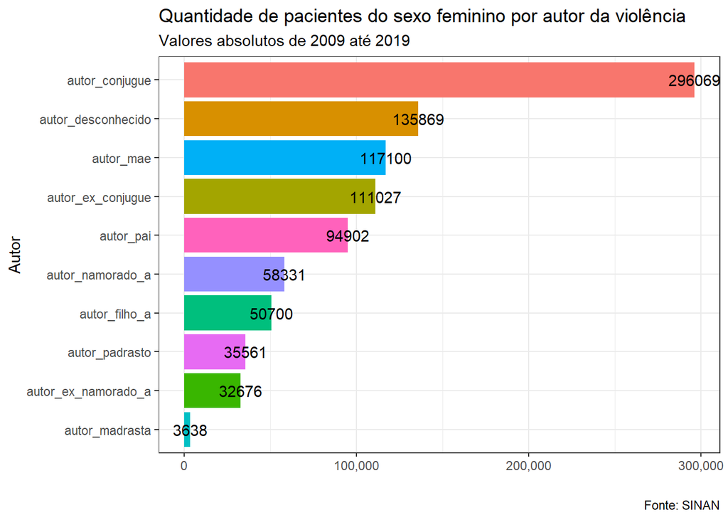

```r
autor_violencia_mulher %>%
  ggplot(aes(x=reorder(autor, numero_casos),
             y=numero_casos,
             fill=autor,
             na.rm = TRUE)) +
  geom_bar(stat='identity') +
  labs(x = "Autor", y = "", title = "Raça dos pacientes") +
  coord_flip() +
  scale_y_continuous(labels = comma) +
  theme(legend.position = "none") +
  geom_text(aes(label=numero_casos), vjust=0.5) +
  labs(x= "Autor", y= "", color= "",
        title = "Quantidade de pacientes do sexo feminino por autor da violência",
        subtitle = paste0("Valores absolutos de ", min(tb_violencia$ano), " até ", max(tb_violencia$ano)),
        caption = "Fonte: SINAN")
```

O gráfico acima indica que, de fato, boa parte da violência sofrida pelas mulheres é praticada por conjugues, ex-conjugues, namorados, ex-namorados e familiares. O conjugue, por exemplo, é o grupo com maior casos reportados - 296 mil, seguido de autor desconhecido (136 mil), mãe (117 mil) e ex-conjugue (111 mil).

## 3.6 Análise dos casos de violencia entre homens e mulheres, segmentados por raça

Entendido as particulariedades dos grupos, resolvemos nos aprofundar nos agravantes que giram em torno da violência. Para isso usaremos o recurso de gráfico chamado “Spider Plot” ou simplesmente gráfico de radar. No caso, será possível listar algumas características dos casos de violência e contar de forma dinâmica como cada grupo presenciou cada agravante.

Abaixo foi criado uma função que gera os gráficos que serão analisados:

```r
gerar_spider_violencia <- function(tabela, titulo,list_var,col_categoria) {
  # Criacao da Base de dados para o spider - retirando duplicados
  spider_crime <-  tabela[,list_var] %>% drop_na
  # retirando valores diferentes de 1 e 0
  spider_crime[,-1][spider_crime[,-1] != 1] <-0

  #criando variaveis genericas
  count_pop <- spider_crime %>% group_by({{col_categoria}}) %>% summarise(n()) %>% data.frame
  classes_legenda <- spider_crime[[1]] %>% unique

  # group by
  spider_crime <-   spider_crime %>%
                      group_by({{col_categoria}}) %>%
                      summarise(across(everything(), sum)) %>% eval
  spider_crime <- spider_crime %>% data.frame
  spider_crime <-spider_crime[,-1]/count_pop$n..

  # As duas primeiras linhas são referentes ao limite máximo e limite mínimo
  cols_limit <- spider_crime %>% ncol
  spider_crime <-rbind(rep(1,cols_limit) , rep(0,cols_limit) , spider_crime)

  # Cores das classes
  colors_border=c( rgb(0.8,0.2,0.5,0.9) ,rgb(0.2,0.5,0.5,0.9) )
  colors_in=c( rgb(0.8,0.2,0.5,0.4), rgb(0.2,0.5,0.5,0.4)  )

  # Criação do gráfico
  spider_crime %>%
    radarchart(axistype=1,
               # Polígono
               pcol=colors_border , pfcol=colors_in , plwd=4, plty=1 ,
               # Grid do gráfico
               cglcol="grey", cglty=1, axislabcol="grey", cglwd=1.1,
               # Tamanho dos rótulos
               vlcex=0.6
    )
  #Legenda e Título
  legend(x=1.5, y=1.2, legend = classes_legenda, bty = "n", pch=20 , col=colors_border , text.col = "black", cex=0.9, pt.cex=1.6)
  title(titulo)
}
```

Dito isso, seguimos para a visualização de agravantes de violência. Para entender a visualização, imagine que cada vértice do polígno seja uma característica da violência reportada. O gráfico em si mostra a porcentagem de cada vértice em relação ao número total de casos por grupo. Ou seja, se no vértice de “ocorreu violência física” para mulheres foi de 50%, significa que 50% dos casos reportados por mulheres tiveram algum tipo de violência física. Abaixo é apresentado um gráfico de radar separado pelos grupos “Feminino” e “Masculino”:

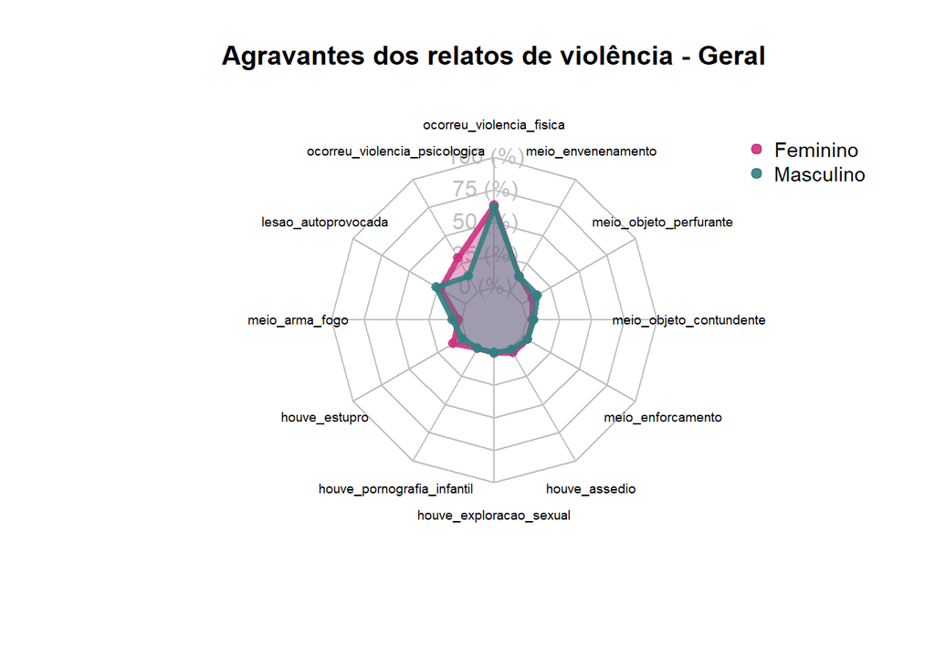

```r
var_usadas_agressao <- c('sexo_paciente_desc'
                ,'ocorreu_violencia_fisica'
                ,'ocorreu_violencia_psicologica'
                ,'lesao_autoprovocada'
                ,'meio_arma_fogo'
                ,'houve_estupro'
                ,'houve_pornografia_infantil'
                ,'houve_exploracao_sexual'
                ,'houve_assedio'
                ,'meio_enforcamento'
                ,'meio_objeto_contundente'
                ,'meio_objeto_perfurante'
                ,'meio_envenenamento')
gerar_spider_violencia(tb_violencia,paste('Agravantes dos relatos de violência - Geral'),var_usadas_agressao,sexo_paciente_desc)
```

No geral, o ato de violência está majoritariamente associado à violência física, e isso não se diferencia por grupo. O que chama atenção é como as mulheres estão relativamente mais sucetíveis a casos como violência psicológica, estupro e assedio. Enquanto isso, quando o meio é arma de fogo, objeto perfurante ou a lesão é auto provocada, o grupo dos homens possui está mais vunerável proporcionalmente.

Podemos ampliar essa visão apenas segregando a base por raça.

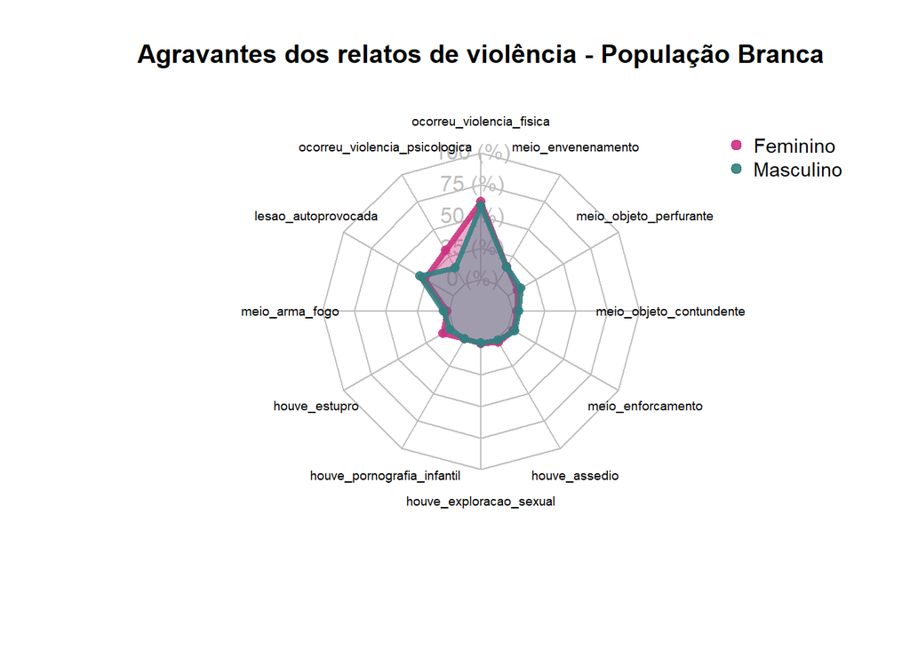

```r
raca='Branca'
gerar_spider_violencia(tb_violencia%>% filter(raca_paciente_desc==raca),paste('Agravantes dos relatos de violência - População',raca),var_usadas_agressao,sexo_paciente_desc)
```

A população branca apresenta um comportamento muito parecido com a média. Isso se deve porque já foi comprovado uma grande presença de pessoas brancas na base. Com certeza, esse efeito desloca a média para uma situação mais parecida com o cenário de violência em que a população branca foi vítima. Vamos ver se esse cenário de próximo a média tende a se repetir a população parda:

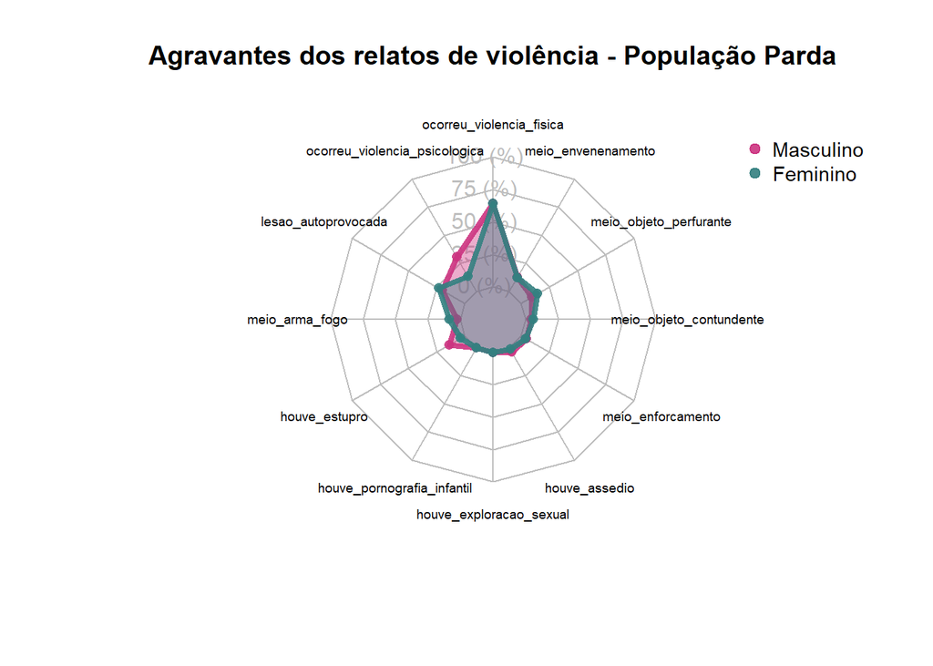

```r
raca='Parda'
gerar_spider_violencia(tb_violencia%>% filter(raca_paciente_desc==raca),paste('Agravantes dos relatos de violência - População',raca),var_usadas_agressao,sexo_paciente_desc)
```

Como previsto, a população parda também tem a mesma distribuição. De fato, por não se tratar de um grupo considerado uma “minoria” racial, brancos e pardos podem ter comportamento muito semelhante. É claro que é possível ver um pequeno aumento em casos de estupro para mulheres pardas em relação ao grupo de pessoas brancas, mas as diferenças são pequenas.

A hipótese é que a questão étnica seja mais agravante, como no caso de pretos e indígenas

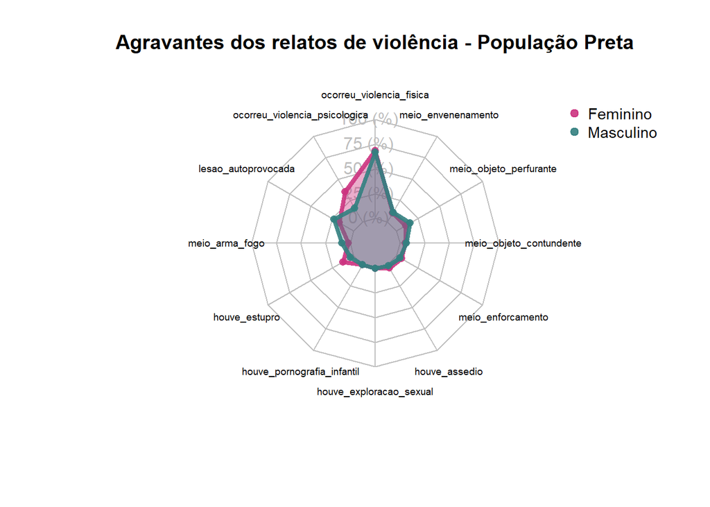

```r
raca='Preta'
gerar_spider_violencia(tb_violencia%>% filter(raca_paciente_desc==raca),paste('Agravantes dos relatos de violência - População',raca),var_usadas_agressao,sexo_paciente_desc)
```

Nesse grafico voltado a população negra, notamos que a violencia fisica se desloca para quase 70% dos casos, assim, temos que a violencia fisica aparenta ser mais incidente contra negros do que contra brancos. Para mulheres, houve um leve aumento relativo a casos de estupro e também a psicológica sofrida por mulheres se deloca um pouco, ultrapassando mais de 30% dos casos. Para homens negros, os casos de objeto perfurante também ficam um pouco maiores em relação a média.

Por fim, analisamos a população indígena.

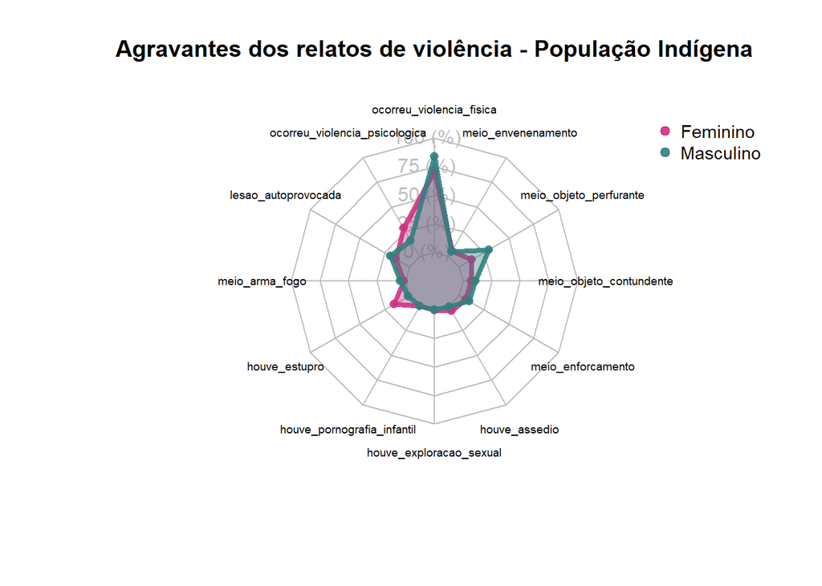

```r
raca='Indígena'
gerar_spider_violencia(tb_violencia%>% filter(raca_paciente_desc==raca),paste('Agravantes dos relatos de violência - População',raca),var_usadas_agressao,sexo_paciente_desc)
```

Para os indígenas, os agravantes de violência mudam bastante. Inicialmente, notamos que os casos reportados de violência física contra indígenas são maiores que a população negra e branca proporcionalmente, alcaçando um número superior a 75% para homens. Ainda nos homens indígenas, temos que violencia por objeto perfurante ultrapassa 25% dos casos, enquanto nos outros grupos não chegava a 20%. Nas mulheres indígenas, os casos de estupros ficam mais comuns, porém casos de lesões autoprovocadas mais raros.

Essa análise foi interessante para explorar e entender como cada grupo está sucetível a violência, porém notamos que talvez o autor da violência também possa variar conforme o grupo alvo.

Abaixo a visão de tipo de autores de violência propocionais a grupos de homens e mulheres - ainda não discriminado por raça.

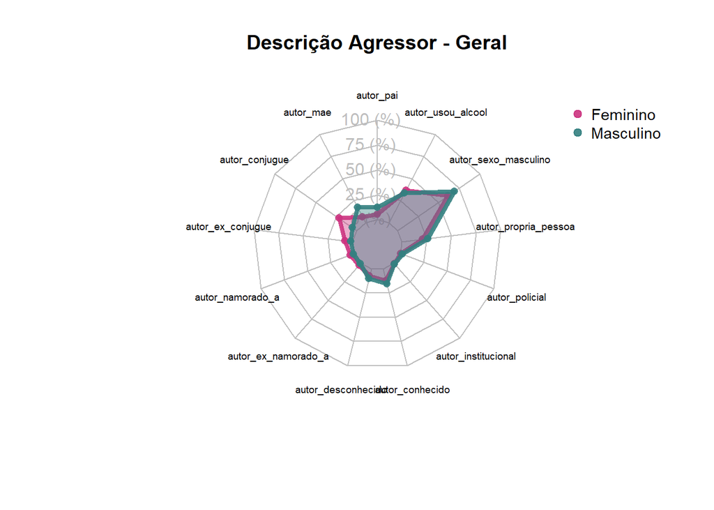

```r
#Criação de nova coluna binária se o autor é do sexo masculino
tb_violencia <- tb_violencia %>%  mutate(autor_sexo_masculino= ifelse(autor_sexo_desc == 'Masculino' , 1,0))

var_usadas_autor <- c('sexo_paciente_desc'
                ,"autor_pai"
                ,"autor_mae"
                ,"autor_conjugue"
                ,"autor_ex_conjugue"
                ,"autor_namorado_a"
                ,"autor_ex_namorado_a"
                ,"autor_desconhecido"
                ,"autor_conhecido"
                ,"autor_institucional"
                ,"autor_policial"
                ,"autor_propria_pessoa"
                ,"autor_sexo_masculino"
                ,"autor_usou_alcool")


gerar_spider_violencia(tb_violencia,paste('Descrição Agressor - Geral'),var_usadas_autor,sexo_paciente_desc)
```

Vamos apresentar a segregação novamente para os três grupos, na mesma sequencia. Primeiro falaremos sobre a população branca e parda.

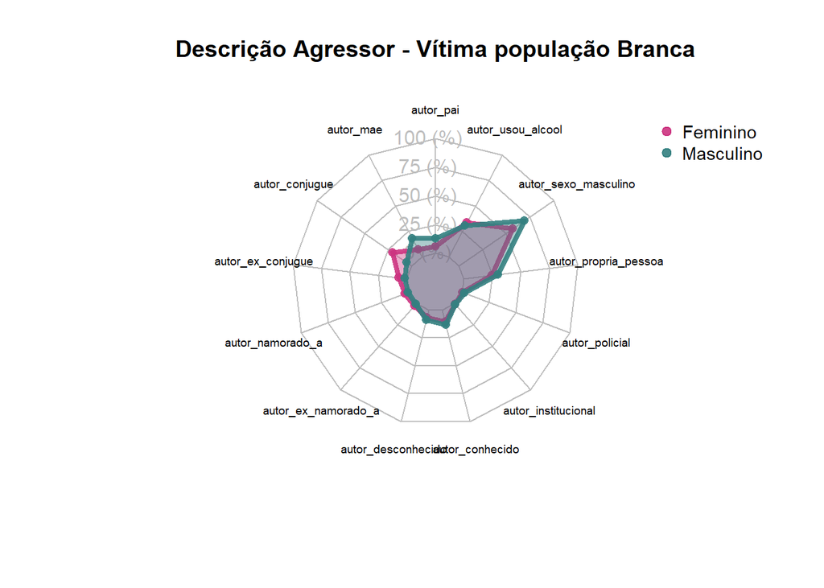

```r
raca='Branca'
gerar_spider_violencia(tb_violencia%>% filter(raca_paciente_desc==raca),paste('Descrição Agressor - Vítima população',raca),var_usadas_autor,sexo_paciente_desc)
```

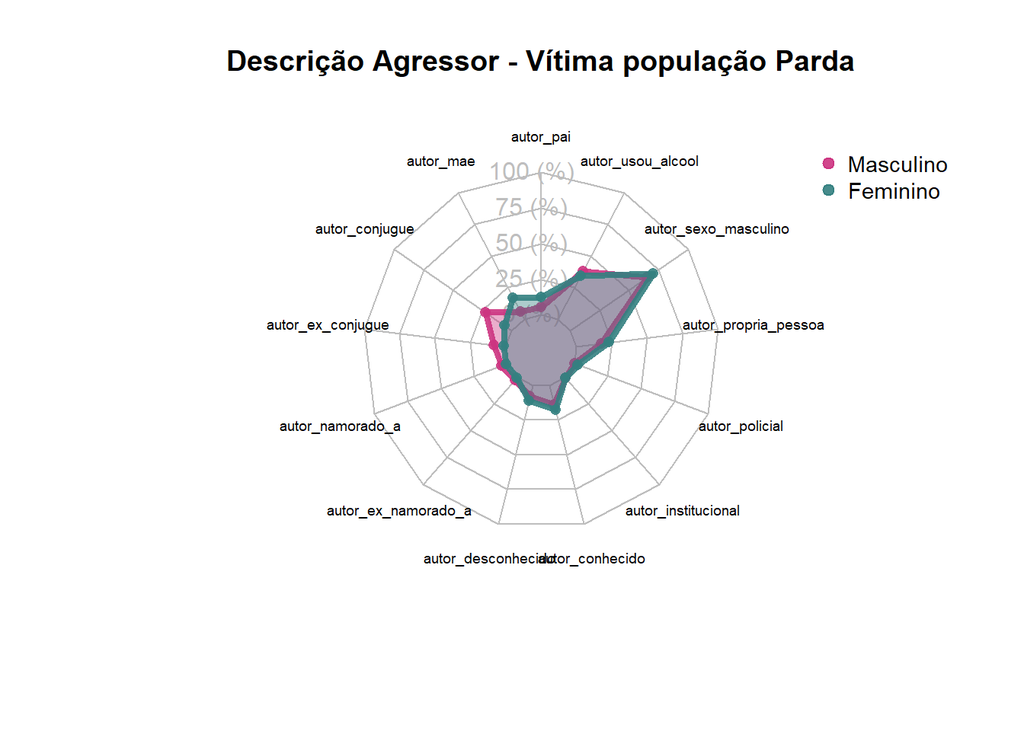

```r
raca="Parda"
gerar_spider_violencia(tb_violencia%>% filter(raca_paciente_desc==raca),paste("Descrição Agressor - Vítima população",raca),var_usadas_autor,sexo_paciente_desc)
```

Novamente, temos uma distribuição muito parecida com a população como um todo. Seguimos para a população negra.

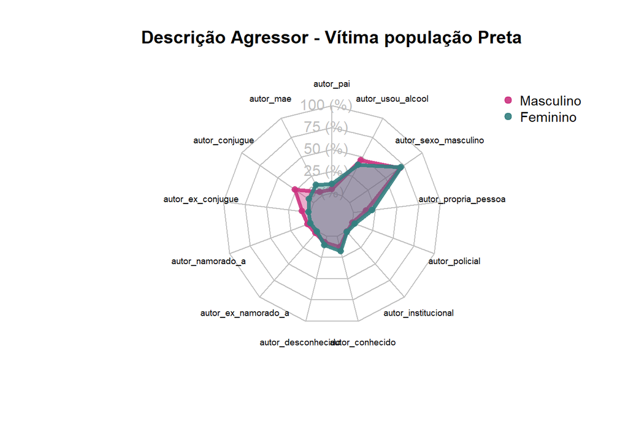

```r
raca="Preta"
gerar_spider_violencia(tb_violencia%>% filter(raca_paciente_desc==raca),paste('Descrição Agressor - Vítima população',raca),var_usadas_autor,sexo_paciente_desc)
```

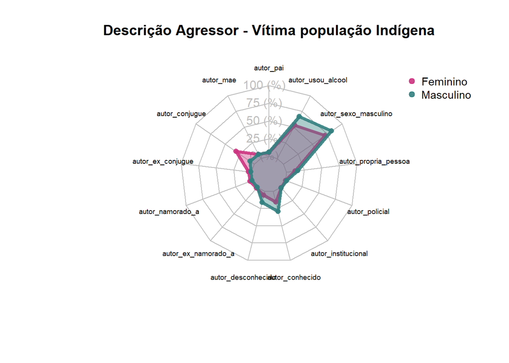

```r
raca="Indígena"
gerar_spider_violencia(tb_violencia%>% filter(raca_paciente_desc==raca),paste("Descrição Agressor - Vítima população",raca),var_usadas_autor,sexo_paciente_desc)
```

Por fim, novamente as maiores diferenças se encontram na segmentação por indígenas. No caso, de homens indígenas, quase 80% dos casos de violência são cometidos por homens e quase 75% desses casos quando o autor está alcoolizado. Outro movimento interessante é pouca participação de agressões cometidas por familiares em relação a outros grupos. Por fim, para homens ingígenas, mais de 25% dos seus agressores são conhecidos - número bem maior do que em relação as outras etnias. Para as mulheres indígenas, percebe-se a mesma realidade quanto aos seus agressores que a mulheres negra vivencia: mais de 25% dos casos realizado por conjugues, com uma grande presença de agressores masculinos (75%) e alcoolizados (50%).

## 3.7 Visão por região

Uma vez explorada a visão segmentada por diferentes grupos, sob óticas diferentes, cabe agora uma análise rápida de como os dados estão distribuídos ao longo do país. A fim de solucionar esse problema, foi feito um gráfico de barras empilhada, assim é possível ver a distribuição entre as regiões do país como um gráfico de pizza ao longo do tempo.

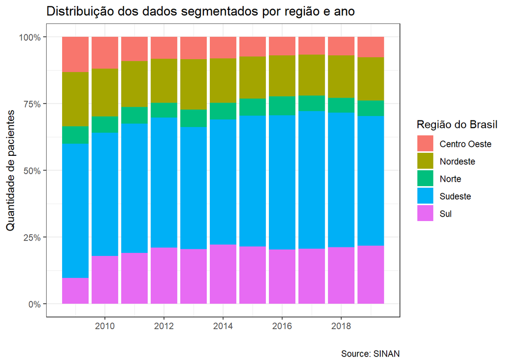

```r
tb_violencia %>% group_by(ano,regiao) %>% summarise(contagem=n(),.groups='drop') %>%
ggplot(aes(fill=regiao, y=contagem, x=ano)) +
  geom_bar(position='fill', stat="identity",width=0.9)+
  scale_y_continuous(labels = scales::percent) +
  scale_x_continuous(breaks= pretty_breaks())+
  labs(x = "",
       y = "Quantidade de pacientes",
       title = "Distribuição dos dados segmentados por região e ano",
       caption = "Source: SINAN",
       fill='Região do Brasil')
```

Apesar de uma leve mudança nos anos iniciais, podemos concluir que a distribuição de dados ao longo dos estados se seguiu constante. Uma segunda análise é chegar se a distribuição entre homens e mulheres muda de acordo com a região, bem como a distribuição de idades também.

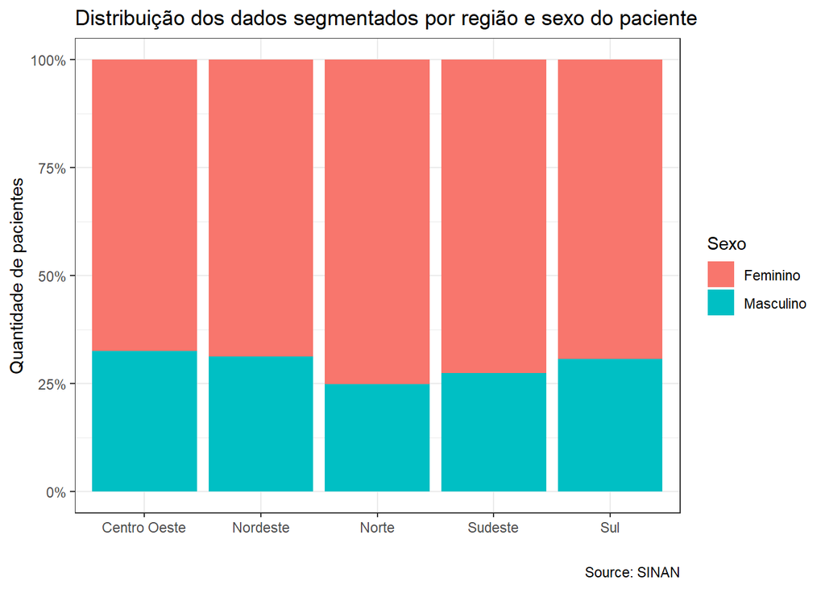

```r
tb_violencia %>% group_by(regiao,sexo_paciente_desc) %>% summarise(contagem=n(),.groups='drop') %>% drop_na() %>%
ggplot(aes(fill=sexo_paciente_desc, y=contagem, x=regiao)) +
  geom_bar(position='fill', stat="identity",width=0.9)+
  scale_y_continuous(labels = scales::percent) +
  #scale_x_continuous(breaks= pretty_breaks())+
  labs(x = "",
       y = "Quantidade de pacientes",
       title = "Distribuição dos dados segmentados por região e sexo do paciente",
       caption = "Source: SINAN",
       fill='Sexo')
```

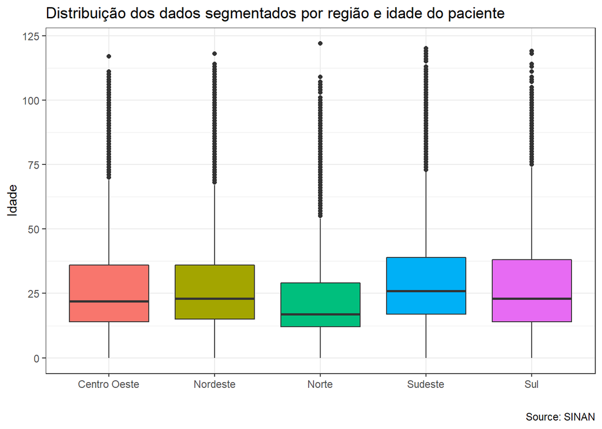

```r
tb_violencia[ , c("regiao", "idade_paciente")] %>%
  filter(!is.na(idade_paciente)) %>%
  rename(., idade = idade_paciente) %>%
  group_by(regiao) %>%
  mutate(regiao = as.character(regiao)) %>%
  ggplot(aes(x=regiao, y=idade, fill=regiao)) +
  geom_boxplot() +
    labs(x = "",
       y = "Idade",
       title = "Distribuição dos dados segmentados por região e idade do paciente",
       caption = "Source: SINAN") +
  theme(legend.position = "none")
```

Em ambos os gráficos, a região Norte se destaca em relação as demais regiões. No caso, existem mais ocorrências de violencia para vítimas do sexo feminino em idades menores. Visto esse comportamento, vale a pena analisar como as etnias estão distribuídas por região e, mais adiante, como é a natureza de cada violência para entender melhor esse fenômeno.

[figure not shown]

```r
tb_violencia %>% group_by(regiao,raca_paciente_desc) %>% summarise(contagem=n(),.groups='drop') %>% drop_na() %>%
ggplot(aes(fill=raca_paciente_desc, y=contagem, x=regiao)) +
  geom_bar(position='fill', stat="identity",width=0.9)+
  scale_y_continuous(labels = scales::percent) +
  #scale_x_continuous(breaks= pretty_breaks())+
  labs(x = "",
       y = "Quantidade de pacientes",
       title = "Distribuição dos dados segmentados por região e sexo do paciente",
       caption = "Source: SINAN",
       fill='Raça')
```

Talvez a presença desse grupo, que está sucessitível a agressões divergentes aos demais grupos étnicos fosse o sufiente para justificar a porque a a região Norte estava se descolando das outras regiões. Porém a população indígena se concentra tanto no Norte quanto no Centro Oeste, região que não está diferente do resto da populaçao. Sendo assim, o problema não é exclusivo porque existem grupos distintos, mas porque a região Norte possui um padrão de violência diferente das demais regiões.